# Homework 4

Rolando Santos - https://github.com/rsantos2032/DSCI401

2023-10-21

```r
library(tidyverse)
library(Lahman)
library(mosaicData)
library(ggplot2)
```

### Question 1: Answer the questions below:

#### a. Use the HELPrct data from the mosaicData to calculate the mean of all numeric variables (be sure to exclude missing values).

```r
head(HELPrct[, 1:6])
```

```
##   age anysubstatus anysub cesd d1 daysanysub
## 1  37            1    yes   49  3        177
## 2  37            1    yes   30 22          2
## 3  26            1    yes   39  0          3
## 4  39            1    yes   15  2        189
## 5  32            1    yes   39 12          2
## 6  47            1    yes    6  1         31
```

```r
HELPrct %>%
  select(where(is.numeric)) %>%
  map_dbl(mean, na.rm = TRUE)
```

```
##              age     anysubstatus             cesd               d1
##       35.6534216        0.7723577       32.8476821        3.0596026
##       daysanysub         dayslink         drugrisk              e2b
##       75.3073770      255.6055684        1.8871681        2.5046729
##           female               i1               i2               id
##        0.2362031       17.9072848       24.5474614      233.4017660
##           indtot       linkstatus              mcs              pcs
##       35.7284768        0.3781903       31.6766783       48.0485416
##           pss_fr          sexrisk       avg_drinks       max_drinks
##        6.7064018        4.6423841       17.9072848       24.5474614
## hospitalizations
##        3.0596026
```

#### b. Find the mean of all the numeric variables stratified by sex and age group where age groups are defined as ranges of 10 years (i.e. 0-10, 10-20, 20-30, etc).

```r
create_age_group <- function(x){
  floor_val <- floor(x/10) * 10
  roof_val <- round(x/10) * 10

  #Checks that an age is divisble by 10
  if (floor_val == roof_val){
    roof_val <- roof_val + 10 #We'll add their age to the next group i.e. 20: 20-30
  }
  return(paste0(floor_val, "-", roof_val))
}
create_age_group <- Vectorize(create_age_group)

HELPrct_age <- HELPrct %>%
  mutate(age_group = create_age_group(age)) %>%
  group_by(sex, age_group) %>%
  summarise_at(.vars = HELPrct %>%
                 select(where(is.numeric)) %>%
                 colnames(), .funs = c(mean = "mean"), na.rm = TRUE)
HELPrct_age
```

```
## # A tibble: 10 × 23
## # Groups:   sex [2]
##    sex    age_group age_mean anysubstatus_mean cesd_mean d1_mean daysanysub_mean
##    <fct>  <chr>        <dbl>             <dbl>     <dbl>   <dbl>           <dbl>
##  1 female 20-30         26.3             0.8        40.3    1.94            64.5
##  2 female 30-40         34.3             0.75       35.5    3.59            86.9
##  3 female 40-50         44.5             0.571      36.9    3.88            89.8
##  4 female 50-60         54               0.6        40.6    5.8             88
##  5 male   10-20         19             NaN          40      1              NaN
##  6 male   20-30         26               0.829      32.9    1.91            77.1
##  7 male   30-40         34.6             0.78       30.3    2.57            75.7
##  8 male   40-50         43.8             0.804      32.5    4.18            67.8
##  9 male   50-60         55               0.714      34.2    6               50.6
## 10 male   60-70         60               1          36     10                6
## # ℹ 16 more variables: dayslink_mean <dbl>, drugrisk_mean <dbl>,
## #   e2b_mean <dbl>, female_mean <dbl>, i1_mean <dbl>, i2_mean <dbl>,
## #   id_mean <dbl>, indtot_mean <dbl>, linkstatus_mean <dbl>, mcs_mean <dbl>,
## #   pcs_mean <dbl>, pss_fr_mean <dbl>, sexrisk_mean <dbl>,
## #   avg_drinks_mean <dbl>, max_drinks_mean <dbl>, hospitalizations_mean <dbl>
```

#### c. Using the data set created in the previous problem, create a set of line plots with the average age of the age group on the x-axis and each of other numeric variables on the y-axis in separate plots stratified by sex. (Note: You are not allowed to use a for loop here or simply copy-and- paste 20 times!)

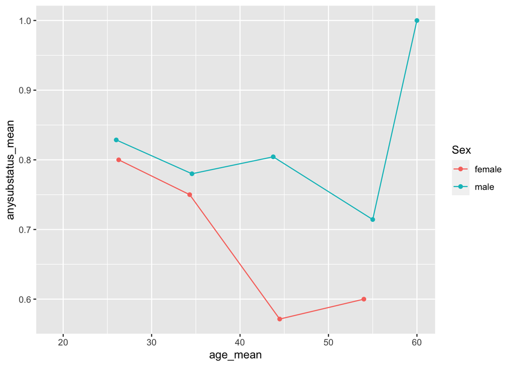

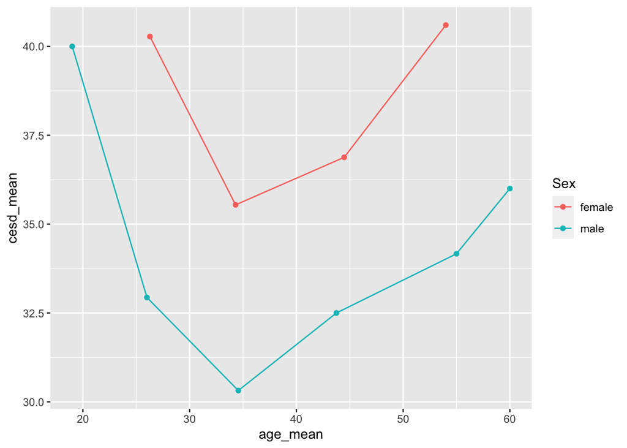

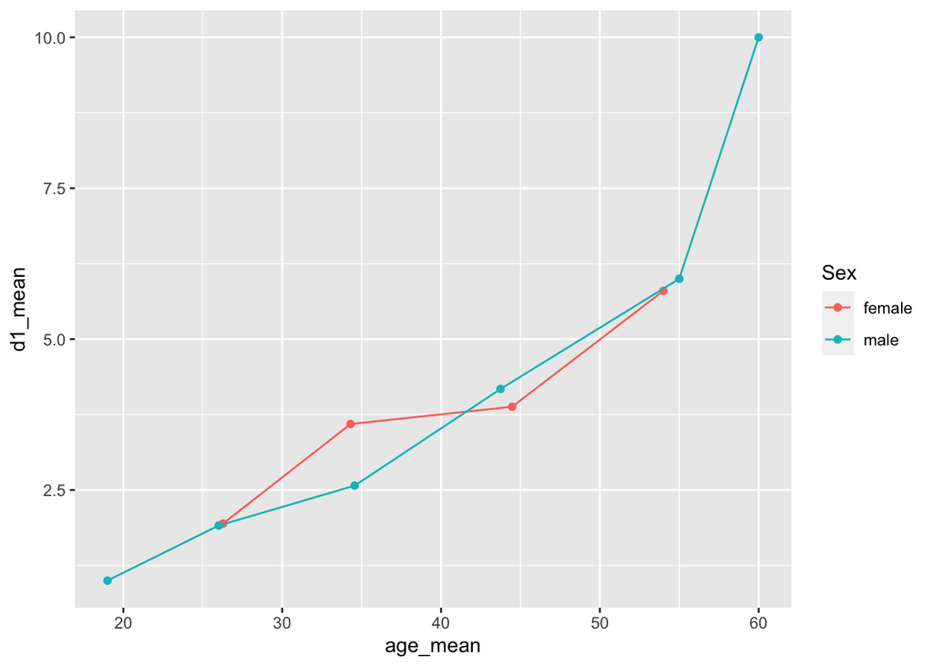

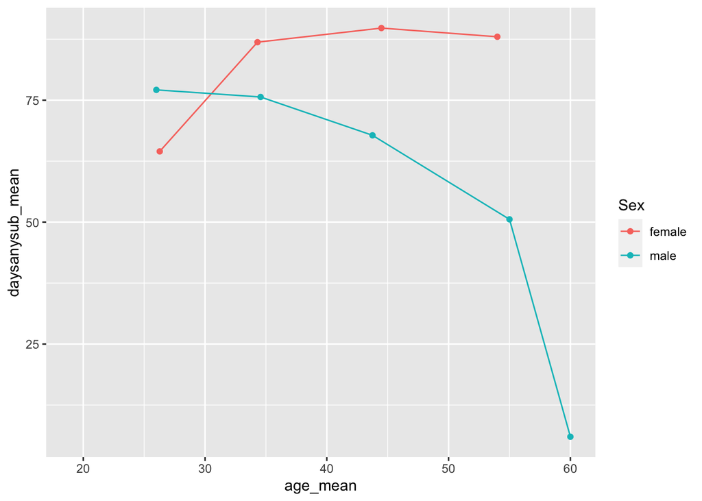

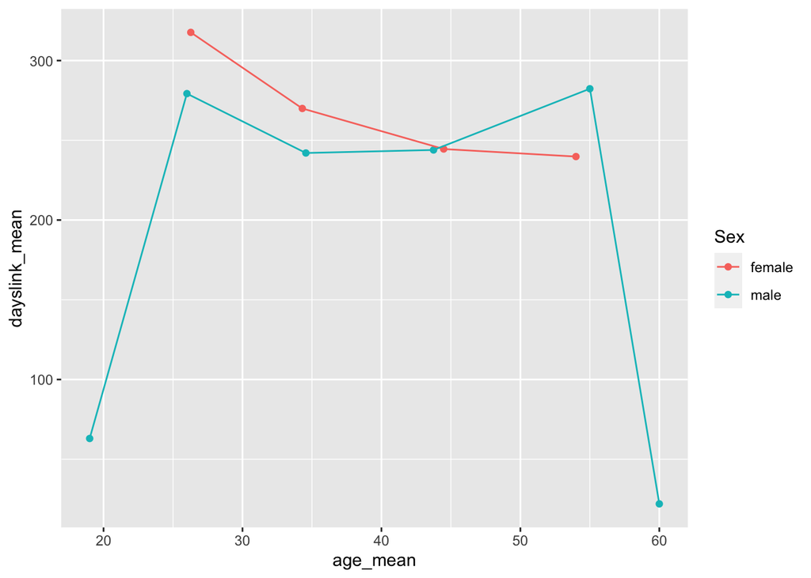

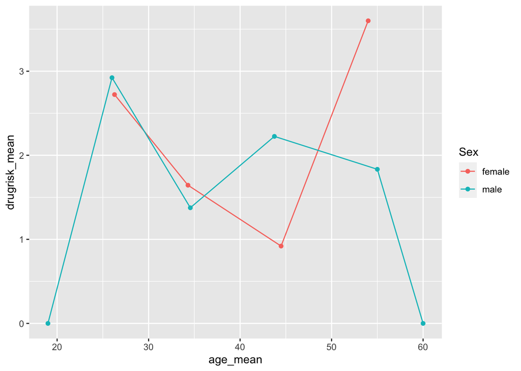

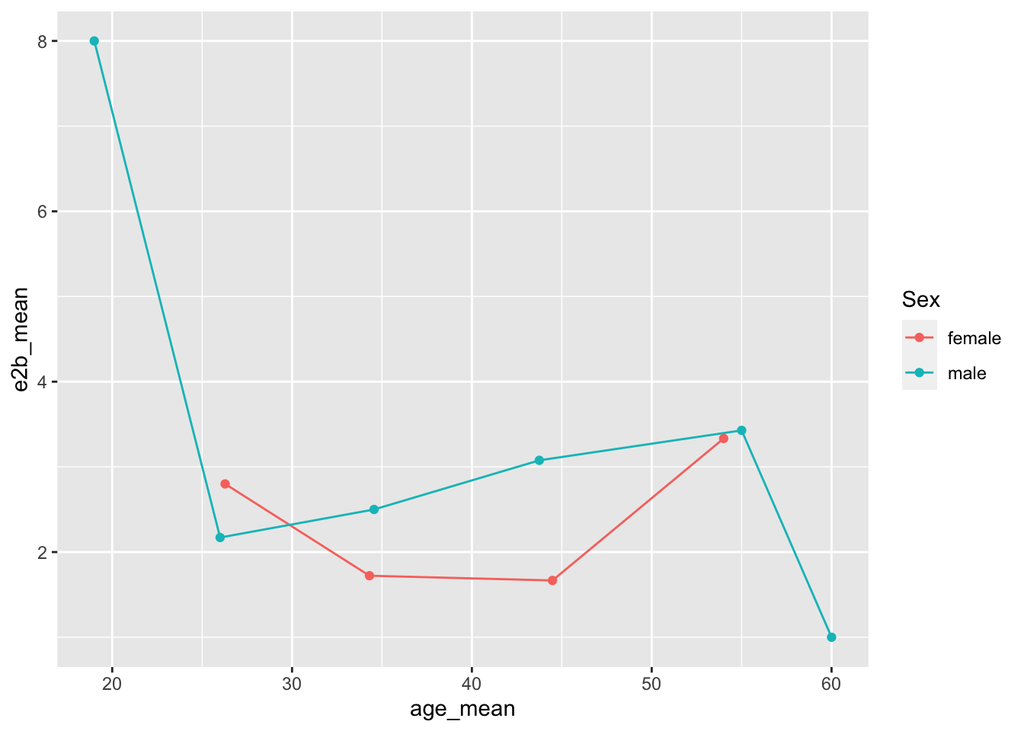

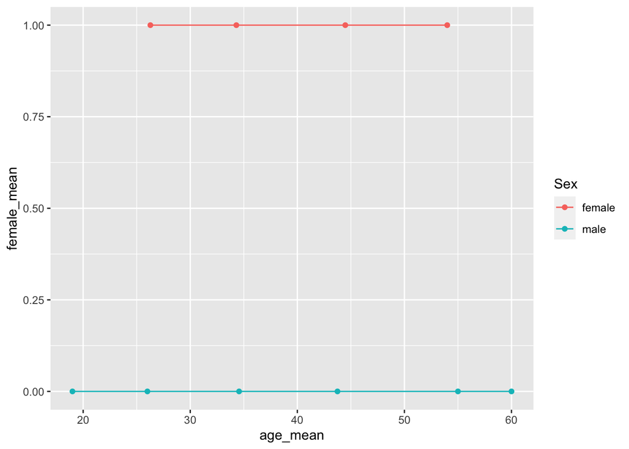

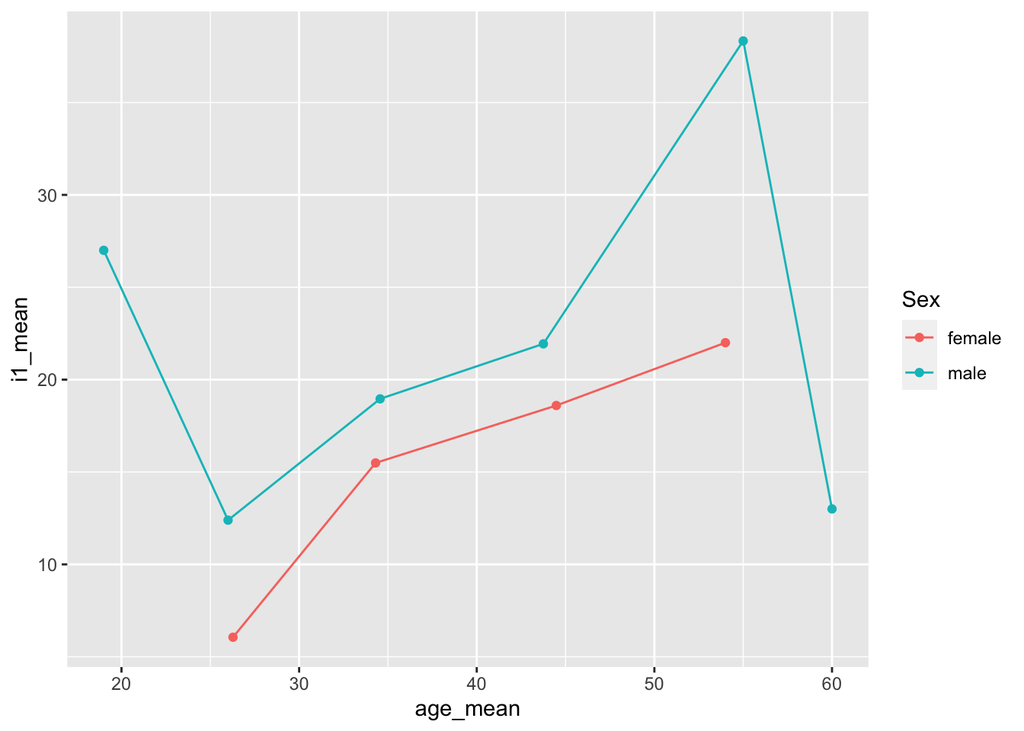

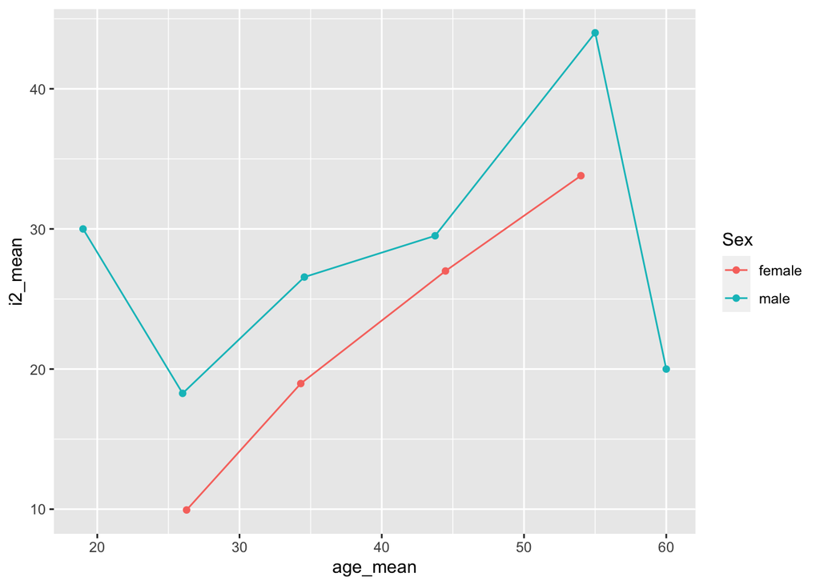

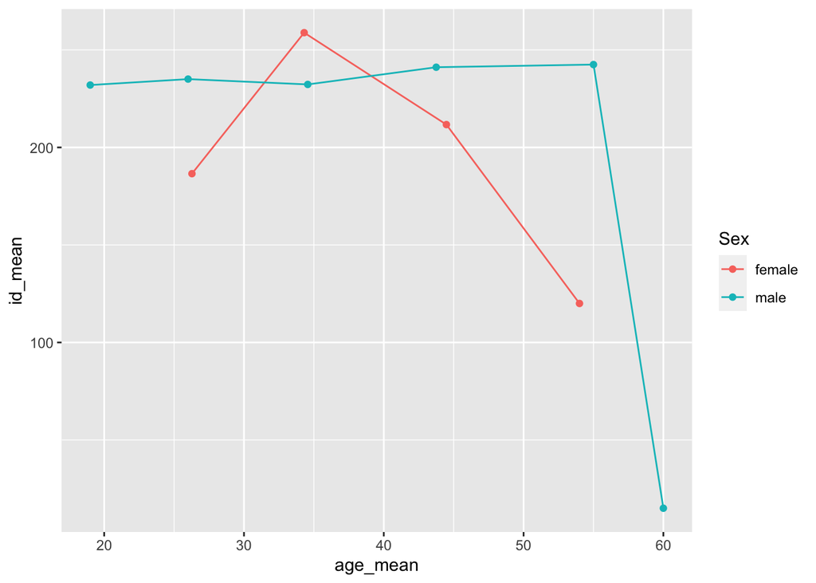

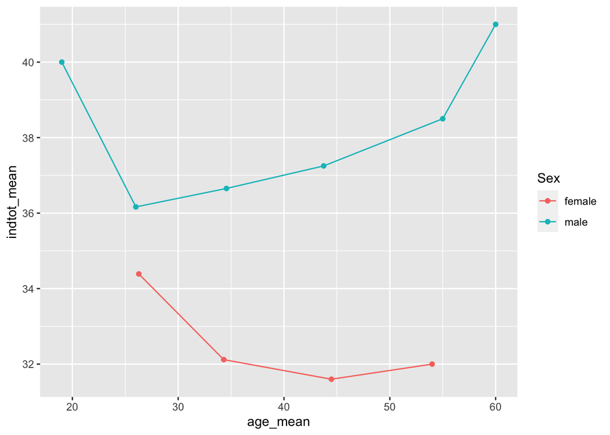

[8 more figures not shown]

[output not shown]

```r
plot_fn <- function(var, data = HELPrct_age){
  return(print(data %>%
    ggplot(
      aes_string(x = "age_mean", y = var, color = "sex")
    ) +
    geom_point() +
    geom_line() +
    labs(color = "Sex")))
}
plot_vfn <- Vectorize(plot_fn)

vars <- HELPrct_age %>% select(contains("_mean")) %>% colnames()
remove <- c("sex", "age_mean")
vars <- vars[!(vars %in% remove)]

plot_vfn(vars)
```

### Question 2: The team IDs corresponding to Brooklyn baseball teams from the Teams data frame from the Lahman package are listed below. Use map int() to find the number of seasons in which each of those teams played by calling a function called count seasons.

```r
head(Teams[, 1:6])
```

```
##   yearID lgID teamID franchID divID Rank
## 1   1871   NA    BS1      BNA  <NA>    3
## 2   1871   NA    CH1      CNA  <NA>    2
## 3   1871   NA    CL1      CFC  <NA>    8
## 4   1871   NA    FW1      KEK  <NA>    7
## 5   1871   NA    NY2      NNA  <NA>    5
## 6   1871   NA    PH1      PNA  <NA>    1
```

```r
bk_teams <- c("BR1", "BR2", "BR3", "BR4", "BRO", "BRP", "BRF")
```

```r
count_seasons <- function(ID, data = Teams){
  num_seasons <- data %>%
    filter(teamID == ID) %>%
    group_by(teamID) %>%
    summarize(num_seasons = sum(n())) %>%
    pull(num_seasons)
  return(num_seasons)
}
total_seasons <- map_int(bk_teams, count_seasons)
total_seasons
```

```
## [1]  1  4  6  1 68  1  2
```

```r
paste0(bk_teams, " has: ", total_seasons, " total season(s)")
```

```
## [1] "BR1 has: 1 total season(s)"  "BR2 has: 4 total season(s)"
## [3] "BR3 has: 6 total season(s)"  "BR4 has: 1 total season(s)"
## [5] "BRO has: 68 total season(s)" "BRP has: 1 total season(s)"
## [7] "BRF has: 2 total season(s)"
```